# Tutorato 3

2026-04-15

## Esercizio 1

Caricare il dataset `student_performance_data.csv` (di cui potete trovare i dettagli su [Kaggle](https://www.kaggle.com/datasets/borovai0/student-performance-analytics-dataset)). Poi:

## 1. Tipologia delle variabili

Classificare tutte le variabili del dataset indicandone:

- **Tipo**: qualitativa / quantitativa
- **Sottotipo**: nominale (dicotomica o meno) / ordinale / discreta / continua

## ✏️ Svolgimento

```r
# Carico dataset
studenti <- read.csv("student_performance_data.csv")

# Prime righe
head(studenti)
```

```
##   student_id gender study_hours_per_day attendance_percentage assignment_score
## 1     100000   Male                4.54                 69.98            36.47
## 2     100001 Female                5.26                 84.80            34.25
## 3     100002   Male                8.69                 73.76            72.29
## 4     100003   Male                4.06                 45.00            97.63
## 5     100004   Male                8.83                 51.13            65.19
## 6     100005 Female                1.79                 53.16            33.61
##   midterm_score final_exam_score participation_score internet_access
## 1         70.70            53.10               17.96             Yes
## 2         27.92            87.17               11.29              No
## 3         70.92            99.61               76.10              No
## 4         31.73            88.85               33.55              No
## 5         78.28            54.23               88.99              No
## 6         54.26            79.79               58.23              No
##   extra_classes parent_education sleep_hours overall_score grade
## 1            No           Master        8.09       52.3480     D
## 2           Yes         Bachelor        4.73       53.9485     D
## 3           Yes              PhD        8.73       82.0375     B
## 4            No         Bachelor        8.22       66.4110     C
## 5            No         Bachelor        8.59       65.6005     C
## 6            No         Bachelor        5.43       59.3525     C
```

```r
# Struttura
str(studenti)
```

```
## 'data.frame':    10000 obs. of  14 variables:
##  $ student_id           : int  100000 100001 100002 100003 100004 100005 100006 100007 100008 100009 ...
##  $ gender               : chr  "Male" "Female" "Male" "Male" ...
##  $ study_hours_per_day  : num  4.54 5.26 8.69 4.06 8.83 ...
##  $ attendance_percentage: num  70 84.8 73.8 45 51.1 ...
##  $ assignment_score     : num  36.5 34.2 72.3 97.6 65.2 ...
##  $ midterm_score        : num  70.7 27.9 70.9 31.7 78.3 ...
##  $ final_exam_score     : num  53.1 87.2 99.6 88.8 54.2 ...
##  $ participation_score  : num  18 11.3 76.1 33.5 89 ...
##  $ internet_access      : chr  "Yes" "No" "No" "No" ...
##  $ extra_classes        : chr  "No" "Yes" "Yes" "No" ...
##  $ parent_education     : chr  "Master" "Bachelor" "PhD" "Bachelor" ...
##  $ sleep_hours          : num  8.09 4.73 8.73 8.22 8.59 5.43 2.84 6.35 5.12 6.33 ...
##  $ overall_score        : num  52.3 53.9 82 66.4 65.6 ...
##  $ grade                : chr  "D" "D" "B" "C" ...
```

```r
# Statistiche
summary(studenti)
```

```
##    student_id        gender          study_hours_per_day attendance_percentage
##  Min.   :100000   Length:10000       Min.   : 1.000      Min.   : 40.00
##  1st Qu.:102500   Class :character   1st Qu.: 3.240      1st Qu.: 55.57
##  Median :105000   Mode  :character   Median : 5.440      Median : 70.74
##  Mean   :105000                      Mean   : 5.525      Mean   : 70.48
##  3rd Qu.:107499                      3rd Qu.: 7.780      3rd Qu.: 85.20
##  Max.   :109999                      Max.   :28.860      Max.   :100.00
##                                      NA's   :87          NA's   :106
##  assignment_score midterm_score    final_exam_score participation_score
##  Min.   :30.00    Min.   : 25.00   Min.   : 30.01   Min.   :10.00
##  1st Qu.:47.32    1st Qu.: 43.52   1st Qu.: 47.40   1st Qu.:32.95
##  Median :64.77    Median : 62.05   Median : 65.21   Median :55.05
##  Mean   :64.72    Mean   : 62.32   Mean   : 64.98   Mean   :55.10
##  3rd Qu.:81.76    3rd Qu.: 81.23   3rd Qu.: 82.50   3rd Qu.:77.76
##  Max.   :99.99    Max.   :100.00   Max.   :100.00   Max.   :99.99
##
##  internet_access    extra_classes      parent_education    sleep_hours
##  Length:10000       Length:10000       Length:10000       Min.   :2.235
##  Class :character   Class :character   Class :character   1st Qu.:5.200
##  Mode  :character   Mode  :character   Mode  :character   Median :6.510
##                                                           Mean   :6.489
##                                                           3rd Qu.:7.790
##                                                           Max.   :9.000
##                                                           NA's   :104
##  overall_score      grade
##  Min.   :33.26   Length:10000
##  1st Qu.:56.53   Class :character
##  Median :63.78   Mode  :character
##  Mean   :63.83
##  3rd Qu.:71.17
##  Max.   :96.88
##  NA's   :104
```

```r
# Controllo NA
colSums(is.na(studenti))
```

```
##            student_id                gender   study_hours_per_day
##                     0                     0                    87
## attendance_percentage      assignment_score         midterm_score
##                   106                     0                     0
##      final_exam_score   participation_score       internet_access
##                     0                     0                     0
##         extra_classes      parent_education           sleep_hours
##                     0                     0                   104
##         overall_score                 grade
##                   104                     0
```

## 💥 Risposte

a): student_id è una variabile **quantitativa discreta**.

b): gender è una variabile **qualitativa nominale**.

c): study_hours_per_day è una variabile **quantitativa continua**.

d): attendance_percentage è una variabile **quantitativa continua**.

e): assignment_score, midterm_score, final_exam_score e participation_score sono variabili **quantitative continue**.

f): internet_access ed extra_classes sono variabili **qualitative nominali dicotomiche**.

g): parent_education è una variabile **qualitativa nominale**.

h): sleep_hours e overall_score sono variabili **quantitative continue**.

i): grade è una variabile **qualitativa ordinale**.

## 2. Ricodifica delle variabili

1. Dopo aver verificato la presenza di NA (come sono rappresentati e quanti sono per variabile?), rimuovere dal dataset le osservazioni contenenti almeno un valore mancante;
2. Alcune variabili qualitative possono essere trasformate in factor direttamente, altre no; perché?
3. Dopo aver trasformato le variabili qualitative in factor, riordinare i livelli ove necessario;
4. Si consideri la variabile `study_hours_per_day` e si aggiunga al dataset una nuova variabile `study_time` che abbia, per ogni osservazione:
- `low` se `study_hours_per_day` è minore di 3,
- `medium` se è compresa tra 3 e 6,
- `high` altrimenti.
5. Si consideri la variabile `attendance_percentage` e si aggiunga al dataset un nuova variabile `attendance` che abbia, per ogni osservazione:
- `low` se `attendance_percentage` è minore di 60,
- `medium` se è compresa tra 60 e 80,
- `high` altrimenti.

## ✏️ Svolgimento

```r
# Controllo NA
colSums(is.na(studenti))
```

```
##            student_id                gender   study_hours_per_day
##                     0                     0                    87
## attendance_percentage      assignment_score         midterm_score
##                   106                     0                     0
##      final_exam_score   participation_score       internet_access
##                     0                     0                     0
##         extra_classes      parent_education           sleep_hours
##                     0                     0                   104
##         overall_score                 grade
##                   104                     0
```

```r
# Rimuovo righe con NA
studenti_clean <- na.omit(studenti)

# Trasformo variabili in factor
studenti_clean$gender <- as.factor(studenti_clean$gender)
studenti_clean$internet_access <- as.factor(studenti_clean$internet_access)
studenti_clean$extra_classes <- as.factor(studenti_clean$extra_classes)
studenti_clean$parent_education <- as.factor(studenti_clean$parent_education)

# Trasformo grade in factor ORDINATO
studenti_clean$grade <- factor(
  studenti_clean$grade,
  levels = c("F","D","C","B","A"),
  ordered = TRUE
)

# Nuova variabile study_time
studenti_clean$study_time <- cut(
  studenti_clean$study_hours_per_day,
  breaks = c(-Inf, 3, 6, Inf),
  labels = c("low", "medium", "high")
)

# Nuova variabile attendance
studenti_clean$attendance <- cut(
  studenti_clean$attendance_percentage,
  breaks = c(-Inf, 60, 80, Inf),
  labels = c("low", "medium", "high")
)
```

## 💥 Risposte

a): I valori mancanti sono rappresentati come **NA**. Sono presenti in:  
- study_hours_per_day (87),  
- attendance_percentage (106),  
- sleep_hours (104)  
- overall_score (104).

Le osservazioni contenenti almeno un valore mancante sono state rimosse dal dataset.

b): Le variabili qualitative possono essere trasformate in factor quando rappresentano categorie. Tuttavia, alcune variabili (come grade) non possono essere trasformate direttamente perché sono **ordinali** e richiedono un ordine tra i livelli.

c): Dopo la trasformazione in factor, i livelli devono essere riordinati per le variabili ordinali (ad esempio grade), in modo da rispettare l’ordine logico (es. A > B > C > D).

d): È stata creata la variabile study_time che classifica study_hours_per_day in **low**, **medium** e **high**.

e): È stata creata la variabile attendance che classifica attendance_percentage in **low**, **medium** e **high**.

## 3. Analisi delle variabili

1. Considerare le variabili `overall_score`, `study_hours_per_day` e `sleep_hours` e calcolarne:
- indici di **posizione**;
- indici di **dispersione**;
- indici di **simmetria**.
2. Costruire la tabella delle frequenze assolute e relative di `study_time` e `attendance` e rappresentarle con uno strumento grafico appropriato;
3. Costruire la tabella di contingenza di `study_time` e `attendance` con la variabile `grade` e rappresentarle con uno strumento grafico appropriato;
4. Costruire la tabella contenente la distribuzione di `grade` condizionata a `study_time`; cosa possiamo dire?
5. Calcolare le medie di `overall_score` per gruppo rispetto a `study_time` e `attendance`; quale gruppo ha la media più alta?
6. Costruire i boxplot di `overall_score` condizionato a `study_time` e a `attendance`; cosa possiamo dire?
7. Calcolare la media di `overall_score` per ogni combinazione di `study_time` e `attendance`; esiste un effetto combinato tra le due variabili?
8. Considerare la distribuzione di `overall_score` e:
- rappresentarla tramite istogramma e curva di densità, aggiungendo al plot anche una linea rossa ad indicarne la media;
- costruire la funzione di ripartizione empirica e confrontarla con una distribuzione teorica;
- costruire un grafico quantile-quantile.

## ✏️ Svolgimento

### 🔹 a) Indici di posizione, dispersione e simmetria

```r
# Funzione per calcolare indici principali
indici_variabile <- function(x) {
  c(
    media = mean(x),
    mediana = median(x),
    minimo = min(x),
    massimo = max(x),
    primo_quartile = quantile(x, 0.25),
    terzo_quartile = quantile(x, 0.75),
    varianza = var(x),
    deviazione_standard = sd(x),
    IQR = IQR(x),
    simmetria = mean((x - mean(x))^3) / sd(x)^3
  )
}

# Indici per overall_score
indici_variabile(studenti_clean$overall_score)
```

```
##               media             mediana              minimo             massimo
##        63.819405892        63.787250000        33.263500000        96.879500000
##  primo_quartile.25%  terzo_quartile.75%            varianza deviazione_standard
##        56.512125000        71.160500000       104.565106547        10.225708120
##                 IQR           simmetria
##        14.648375000        -0.002428871
```

```r
# Indici per study_hours_per_day
indici_variabile(studenti_clean$study_hours_per_day)
```

```
##               media             mediana              minimo             massimo
##           5.5241328           5.4300000           1.0000000          28.8600000
##  primo_quartile.25%  terzo_quartile.75%            varianza deviazione_standard
##           3.2300000           7.7775000           7.6316226           2.7625392
##                 IQR           simmetria
##           4.5475000           0.7941345
```

```r
# Indici per sleep_hours
indici_variabile(studenti_clean$sleep_hours)
```

```
##               media             mediana              minimo             massimo
##          6.48560327          6.51000000          2.23500000          9.00000000
##  primo_quartile.25%  terzo_quartile.75%            varianza deviazione_standard
##          5.20000000          7.79000000          2.17354464          1.47429462
##                 IQR           simmetria
##          2.59000000         -0.03431299
```

## 💥 Risposte

- overall_score ha media **63.82**, con distribuzione quasi simmetrica (simmetria ≈ 0) e dispersione moderata (deviazione standard **10.23**).
- study_hours_per_day ha media **5.52**, con distribuzione asimmetrica a destra (simmetria **0.79**) e maggiore variabilità.
- sleep_hours ha media **6.49**, con distribuzione quasi simmetrica e dispersione contenuta (deviazione standard **1.47**).

### 🔹 b) Tabelle frequenze e grafici

```r
# Frequenze study_time
freq_study <- table(studenti_clean$study_time)
freq_study
```

```
##
##    low medium   high
##   2164   3261   4181
```

```r
prop.table(freq_study)
```

```
##
##       low    medium      high
## 0.2252759 0.3394753 0.4352488
```

```r
# Frequenze attendance
freq_att <- table(studenti_clean$attendance)
freq_att
```

```
##
##    low medium   high
##   3079   3226   3301
```

```r
prop.table(freq_att)
```

```
##
##       low    medium      high
## 0.3205288 0.3358318 0.3436394
```

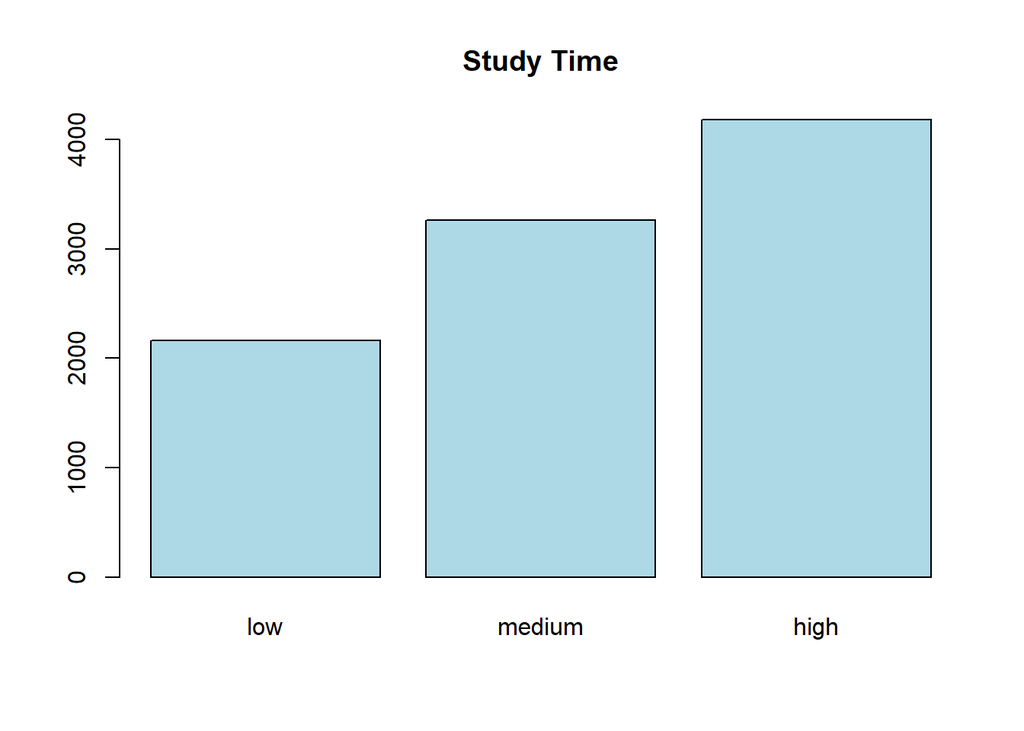

```r
# Grafici
barplot(freq_study, col = "lightblue", main = "Study Time")
```

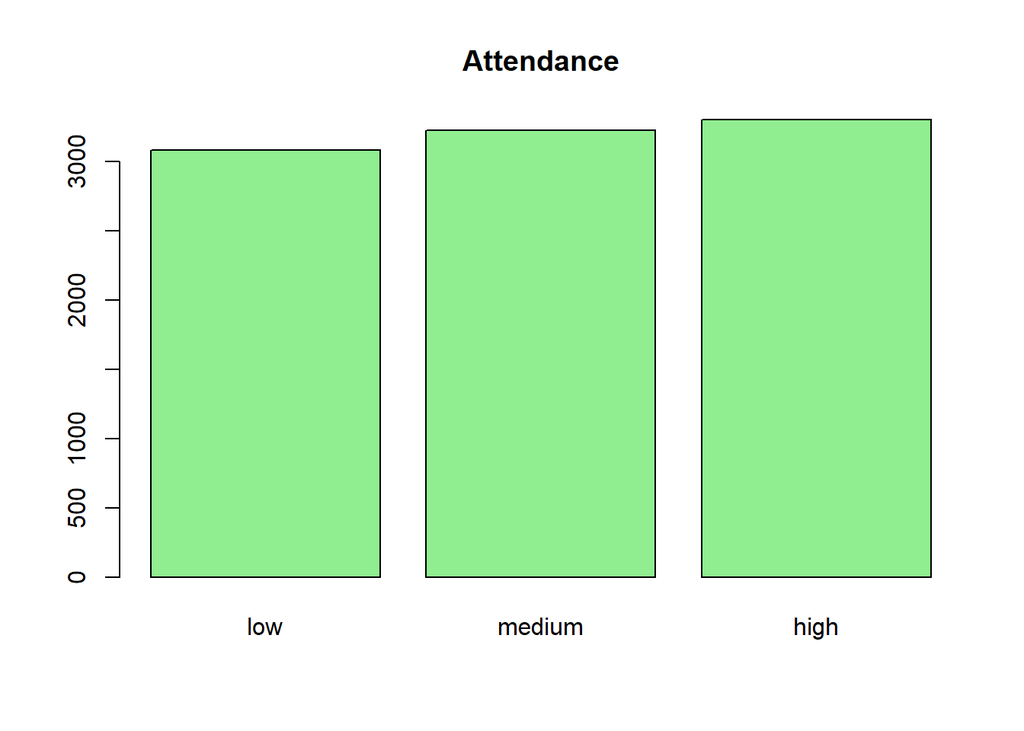

```r
barplot(freq_att, col = "lightgreen", main = "Attendance")
```

## 💥 Risposte

- study_time presenta una maggiore frequenza nella categoria **high (43.52%)**, seguita da **medium (33.95%)** e **low (22.53%)**.
- attendance è distribuita in modo abbastanza uniforme tra **low (32.05%)**, **medium (33.58%)** e **high (34.36%)**.

### 🔹 c) Tabelle di contingenza

```r
# study_time vs grade
tab_study_grade <- table(studenti_clean$study_time, studenti_clean$grade)
tab_study_grade
```

```
##
##             F    D    C    B    A
##   low      13  385  981  550   34
##   medium   17  593 1508  762   42
##   high     22  760 1890 1033   57
```

```r
# attendance vs grade
tab_att_grade <- table(studenti_clean$attendance, studenti_clean$grade)
tab_att_grade
```

```
##
##             F    D    C    B    A
##   low      32  704 1387  621   17
##   medium   17  567 1514  791   42
##   high      3  467 1478  933   74
```

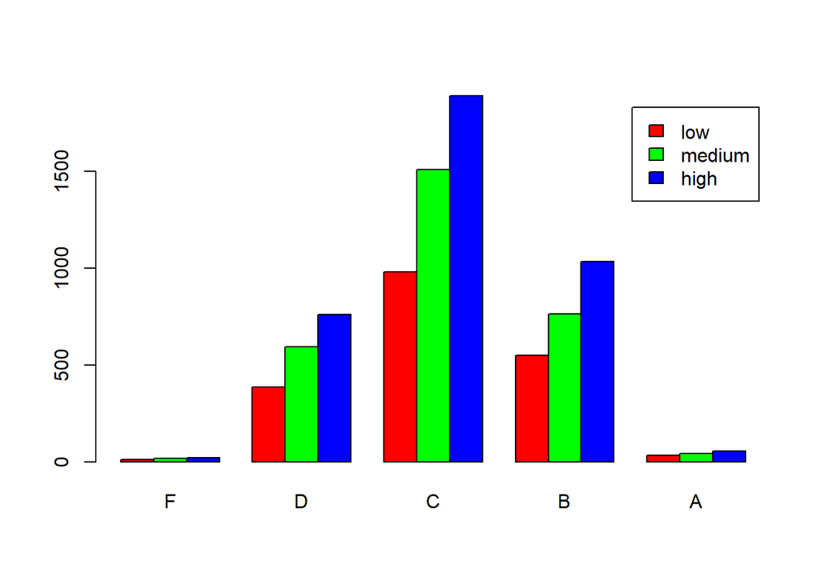

```r
# Grafici
barplot(tab_study_grade, beside = TRUE, legend = TRUE, col = rainbow(3))
```

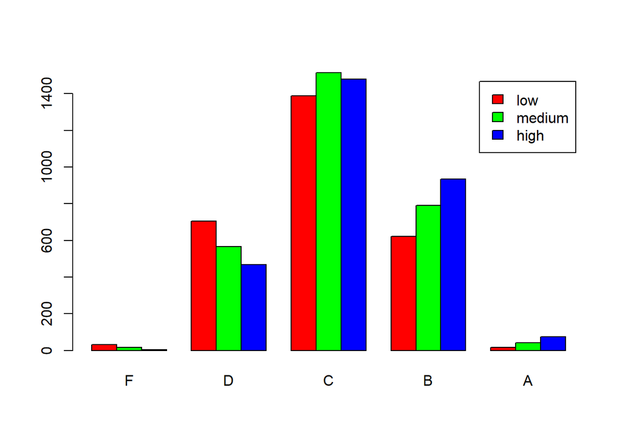

```r
barplot(tab_att_grade, beside = TRUE, legend = TRUE, col = rainbow(3))
```

### 🔹 d) Distribuzione condizionata

```r
# Distribuzione grade condizionata a study_time
prop.table(tab_study_grade, margin = 1)
```

```
##
##                    F           D           C           B           A
##   low    0.006622517 0.196128375 0.499745288 0.280183393 0.017320428
##   medium 0.005817933 0.202943190 0.516084873 0.260780287 0.014373717
##   high   0.005847953 0.202020202 0.502392344 0.274587985 0.015151515
```

## 💥 Risposta

La distribuzione dei voti risulta abbastanza simile tra i diversi livelli di **study_time**. Non si osservano differenze molto marcate, anche se i voti intermedi (in particolare **B e C**) sono i più frequenti in tutti i gruppi.

### 🔹 e) Medie per gruppo

```r
# Media overall_score per study_time
studenti_clean %>%
  group_by(study_time) %>%
  summarise(media = mean(overall_score))
```

```
## # A tibble: 3 × 2
##   study_time media
##   <fct>      <dbl>
## 1 low         64.1
## 2 medium      63.7
## 3 high        63.8
```

```r
# Media overall_score per attendance
studenti_clean %>%
  group_by(attendance) %>%
  summarise(media = mean(overall_score))
```

```
## # A tibble: 3 × 2
##   attendance media
##   <fct>      <dbl>
## 1 low         62.0
## 2 medium      63.9
## 3 high        65.5
```

## 💥 Risposte

- Per study_time, le medie sono molto simili tra i gruppi, con valori leggermente più alti per **low (64.08)**.
- Per attendance, la media più alta si osserva per il gruppo **high (65.46)**, seguito da **medium (63.92)** e **low (61.96)**.

👉 Il gruppo con la media più alta è quindi **attendance high**.

### 🔹 f) Boxplot

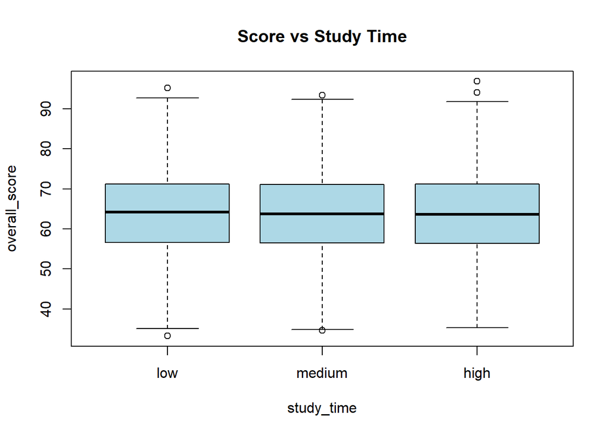

```r
# Boxplot overall_score per study_time
boxplot(overall_score ~ study_time,
        data = studenti_clean,
        col = "lightblue",
        main = "Score vs Study Time")
```

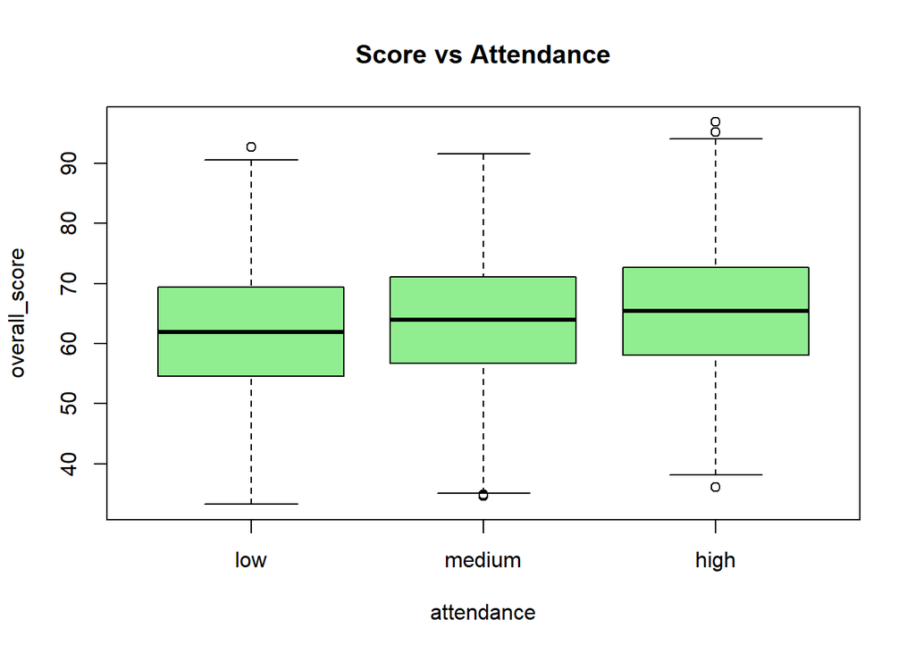

```r
# Boxplot overall_score per attendance
boxplot(overall_score ~ attendance,
        data = studenti_clean,
        col = "lightgreen",
        main = "Score vs Attendance")
```

## 💥 Risposte

- Per study_time, i boxplot risultano molto simili tra i gruppi, con differenze poco marcate nei valori mediani.
- Per attendance, si osserva un leggero aumento dei valori di overall_score passando da **low** a **high**, suggerendo che una maggiore frequenza sia associata a risultati migliori.

### 🔹 g) Effetto combinato

```r
studenti_clean %>%
  group_by(study_time, attendance) %>%
  summarise(media = mean(overall_score), .groups = "drop")
```

```
## # A tibble: 9 × 3
##   study_time attendance media
##   <fct>      <fct>      <dbl>
## 1 low        low         62.4
## 2 low        medium      64.3
## 3 low        high        65.4
## 4 medium     low         61.7
## 5 medium     medium      63.9
## 6 medium     high        65.3
## 7 high       low         61.9
## 8 high       medium      63.8
## 9 high       high        65.6
```

## 💥 Risposta

Si osserva che la media di overall_score aumenta principalmente al crescere di **attendance**, indipendentemente dal livello di study_time.

👉 Non emerge un forte effetto combinato tra le due variabili, ma l’effetto della frequenza (attendance) risulta più rilevante rispetto al tempo di studio.

### 🔹 h) Distribuzione overall_score

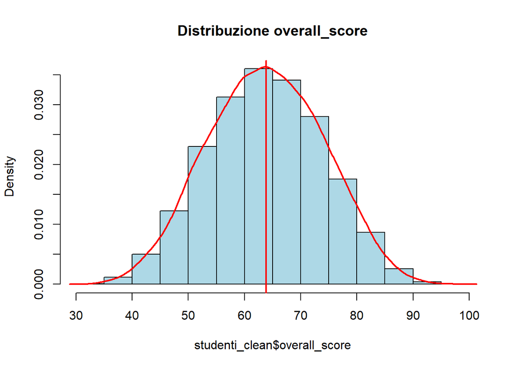

```r
# Istogramma + densità
hist(studenti_clean$overall_score,
     probability = TRUE,
     col = "lightblue",
     main = "Distribuzione overall_score")

lines(density(studenti_clean$overall_score), col = "red", lwd = 2)

# linea media
abline(v = mean(studenti_clean$overall_score), col = "red", lwd = 2)
```

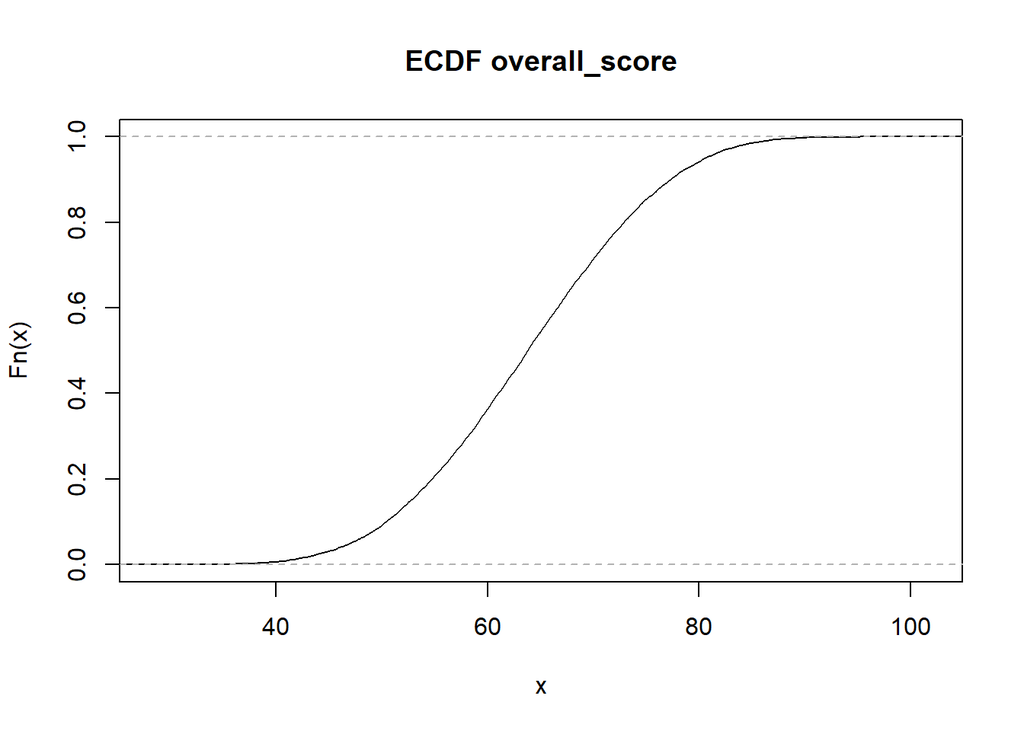

```r
# ECDF
plot(ecdf(studenti_clean$overall_score),
     main = "ECDF overall_score")
```

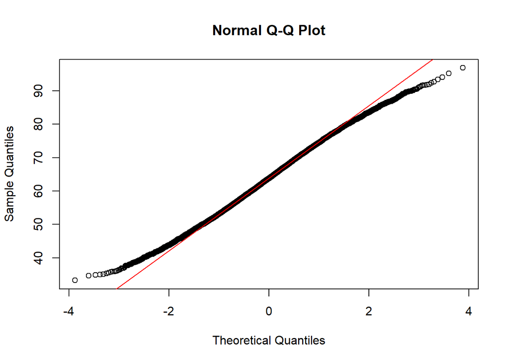

```r
# QQ plot
qqnorm(studenti_clean$overall_score)
qqline(studenti_clean$overall_score, col = "red")
```

## 💥 Risposte

- L’istogramma mostra una distribuzione **circa simmetrica e unimodale**, con forma simile a una distribuzione normale.
- La curva di densità conferma una buona approssimazione a una distribuzione normale, con valori concentrati intorno alla media.
- La funzione di ripartizione empirica (ECDF) presenta un andamento regolare e crescente, coerente con una distribuzione continua.
- Il grafico quantile-quantile (QQ plot) mostra che i punti sono generalmente allineati alla retta, con leggere deviazioni nelle code.

👉 Si può quindi concludere che la distribuzione di overall_score è **approssimativamente normale**.